# 聚类分析

2020/5/21

## 聚类分析结果

数据选取的是2019年GDP前20的国家于3月20日至5月19日每日新增病例的数据

采用层次聚类分析对这 20的国家疫情数据进行分析，得到分类结果如下图所示：

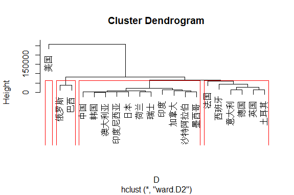

根据上图可知：

第一类：美国

第二类：俄罗斯、巴西

第三类：中国、韩国、澳大利亚、印度尼西亚、 日本、荷兰、瑞士、印度、加拿大、沙特阿拉伯、墨西哥

第四类：法国、西班牙、意大利、德国、英国、土耳其

## 分组特征剖析

第一组：美国

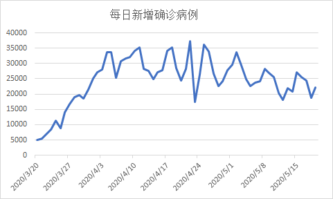

美国如今是全球疫情最严重的国家，很大一部分原因也是由于在疫情爆发的初期政府的不作为。

第二组：俄罗斯、巴西

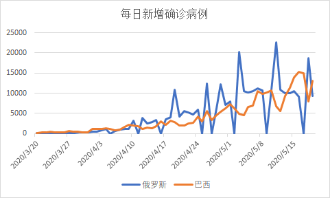

巴西和俄罗斯是全球疫情最为严重的国家之一，累计确诊人数超过了25万，每日新增确诊病例同样还在持续增加，约达到1万左右。

第三类：中国、韩国、澳大利亚、印度尼西亚、日本、荷兰、瑞士、印度、加拿大、沙特阿拉伯、墨西哥

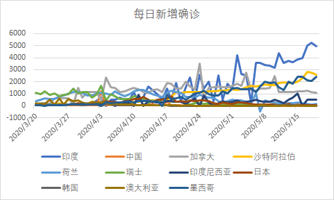

第四类：法国、西班牙、意大利、德国、英国、土耳其

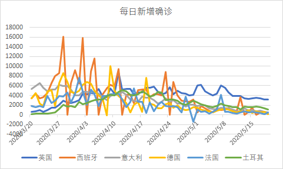

第四类国家均属于欧洲国家，意大利，西班牙，英国，德国，法国这几个国家疫情已趋于稳定，每日新增的确诊病例开始逐步下降。